# 데이터 과학 – 금융(Finance)

재무제표(Financial Statement)

xwMOOC

Tidyverse Korea

2019-01-10

# 1 거래주식 업체코드

코스피(KOSPI)는 한국거래소 **유가증권**시장의 종합주가지수를 이른다. **코스닥**(KOSDAQ)은 한국거래소(KRX)의 코스닥시장본부가 운영하는 주식시장을 통칭한다. [KIND - 상장법인목록](http://kind.krx.co.kr/corpgeneral/corpList.do?method=loadInitPage) 웹사이트에서 **유가증권**, **코스닥**별로 나눠서 검색하고 엑셀파일로 다운로드 받는다.

```r
library(tidyverse)
library(readxl)

kospi_code <- read_excel("data/유가증권.xlsx", sheet="유가증권")
kosdaq_code <- read_excel("data/코스닥.xlsx", sheet="코스닥")

kospi_df <- kospi_code %>%
  mutate(`구분`="코스피")

kosdaq_df <- kosdaq_code %>%
  mutate(`구분`="코스닥")

stock_code_df <- bind_rows(kospi_df, kosdaq_df)

stock_code_df %>%
  select(`구분`, everything()) %>%
  mutate(`홈페이지` = paste0("<a href='", `홈페이지`, "' target='_blank'>", `홈페이지`, "</a>")) %>%
  DT::datatable(escape = FALSE,  filter = 'top')
```

|  | 구분 | 회사명 | 종목코드 | 업종 | 주요제품 | 상장일 | 결산월 | 대표자명 | 홈페이지 | 지역 |
| --- | --- | --- | --- | --- | --- | --- | --- | --- | --- | --- |
| 1 | 코스피 | 에어부산 | 298690 | 항공 여객 운송업 | 항공 여객 및 화물 운송 | 2018-12-27T00:00:00Z | 12월 | 한태근 | http://www.airbusan.com | 부산광역시 |
| 2 | 코스피 | 아시아나IDT | 267850 | 컴퓨터 프로그래밍, 시스템 통합 및 관리업 | IT 서비스, IT 솔루션 | 2018-11-23T00:00:00Z | 12월 | 박세창 | http://www.asianaidt.com | 서울특별시 |
| 3 | 코스피 | 세아제강 | 306200 | 1차 철강 제조업 | 강관 | 2018-10-05T00:00:00Z | 12월 | 이휘령 | http://www.seahsteel.co.kr | 서울특별시 |
| 4 | 코스피 | 하나제약 | 293480 | 의약품 제조업 | 완제의약품 | 2018-10-02T00:00:00Z | 12월 | 이윤하 | http://www.hanaph.co.kr | 경기도 |
| 5 | 코스피 | 우진아이엔에스 | 010400 | 건물설비 설치 공사업 | 반도체/디스플레이 코팅덕트 | 2018-09-14T00:00:00Z | 12월 | 홍평우 | http://www.woojini.com | 서울특별시 |
| 6 | 코스피 | 신한알파리츠 | 293940 | 부동산 임대 및 공급업 | 비거주 부동산 임대 서비스업 | 2018-08-08T00:00:00Z | 03월 | 이준구 | http://www.shalphareit.com | 서울특별시 |
| 7 | 코스피 | 한일시멘트 | 300720 | 시멘트, 석회, 플라스터 및 그 제품 제조업 | 시멘트, 레미콘, 레미탈 | 2018-08-06T00:00:00Z | 12월 | 곽의영 | http://www.hanilcement.com | 서울특별시 |
| 8 | 코스피 | 티웨이항공 | 091810 | 항공 여객 운송업 | 저가 항공운송 | 2018-08-01T00:00:00Z | 12월 | 정홍근 | http://www.twayair.com | 서울특별시 |
| 9 | 코스피 | 롯데정보통신 | 286940 | 컴퓨터 프로그래밍, 시스템 통합 및 관리업 | SM, SI | 2018-07-27T00:00:00Z | 12월 | 마용득 | http://www.ldcc.co.kr | 서울특별시 |
| 10 | 코스피 | 효성중공업 | 298040 | 전동기, 발전기 및 전기 변환 · 공급 · 제어 장치 제조업 | - | 2018-07-13T00:00:00Z | 12월 | 김동우 | http://www.hyosungheavyindustries.com | 서울특별시 |

[output cut: 2100 more lines]

```r
# stock_code_df %>% write_rds("data/stock_code_df.rds")
kospi_df %>% write_rds("data/kospi_df.rds")
kosdaq_df %>% write_rds("data/kosdaq_df.rds")
```

## 1.1 연도별 상장업체

연도별 상장업체를 코스피와 코스닥을 기준으로 상장일을 기준으로 작업한다.

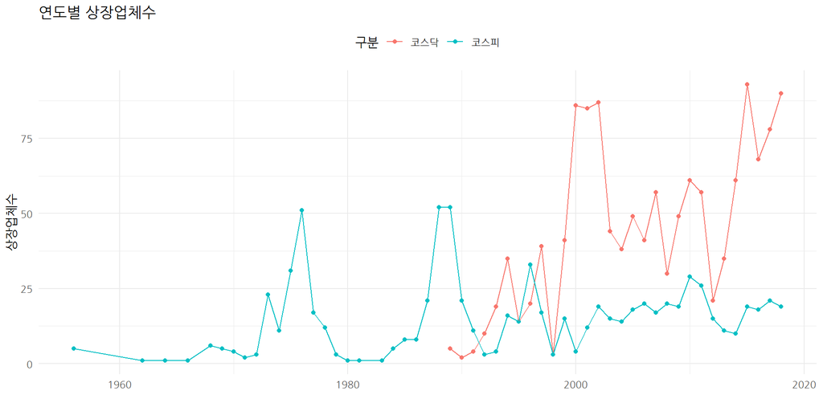

```r
library(lubridate)
library(extrafont)
loadfonts()

stock_code_df %>%
  mutate(`상장년` = year(`상장일`)) %>%
  count(`구분`, `상장년`) %>%
  ggplot(aes(x=`상장년`, y=n, color=`구분`)) +
    geom_point() +
    geom_line() +
    theme_minimal(base_family = "NanumGothic") +
    labs(x="", y="상장업체수", title="연도별 상장업체수") +
    theme(legend.position = "top")
```

## 1.2 결산월

대부분 결산월이 12월이라 12월 결산법인을 제외하고 결산월이 특이한 업체들만 뽑아본다.

```r
stock_code_df %>%
  filter(!str_detect(`결산월`, "12월")) %>%
  group_by(`결산월`) %>%
  summarise(`회사명` = str_c(`회사명`, collapse=", "),
            `종목코드` = str_c(`종목코드`, collapse=", "),) %>%
  DT::datatable()
```

|  | 결산월 | 회사명 | 종목코드 |
| --- | --- | --- | --- |
| 1 | 02월 | 하나니켈1호, 하나니켈2호, 베트남개발1, JTC | 099340, 099350, 096300, 950170 |
| 2 | 03월 | 신한알파리츠, 한국패러랠, 한국ANKOR유전, 기신정기, 동원금속, 대동전자, 신영증권, 오리엔트바이오, 한국주철관공업, SV인베스트먼트, 케이엠제약, SBI핀테크솔루션즈, 이씨에스, 스포츠서울, 3S, 비츠로시스, 피에스엠씨, 모아텍, 메이슨캐피탈, 대신정보통신, 바른손, 제미니투자 | 293940, 168490, 152550, 092440, 018500, 008110, 001720, 002630, 000970, 289080, 225430, 950110, 067010, 039670, 060310, 054220, 024850, 033200, 021880, 020180, 018700, 019570 |
| 3 | 04월 | 트러스제7호 | 140890 |
| 4 | 06월 | 이리츠코크렙, 형지엘리트, 체시스, 세원정공, 만호제강, 신성통상, GRT, 포시에스, 씨케이에이치, 아세아텍, 효성오앤비, 중앙오션, 양지사 | 088260, 093240, 033250, 021820, 001080, 005390, 900290, 189690, 900120, 050860, 097870, 054180, 030960 |
| 5 | 08월 | 풍강 | 093380 |
| 6 | 09월 | 금비, 방림, 아시아종묘, 한스바이오메드, 인터엠 | 008870, 003610, 154030, 042520, 017250 |
| 7 | 11월 | 현대약품 | 004310 |

# 2 주식투자를 위한 기업정보

[NICE 평가정보 상장코스탁분석](http://media.kisline.com/) 웹사이트에서 앞서 준비한 코스피/코스탁 업체코드를 넣어 **Highlight**에서 “Financial Summary” 정보를 가져온다.

## 2.1 특정회사 한개 기업정보

```r
library(tidyverse)
library(rvest)

# kisline_url <- "http://media.kisline.com/highlight/mainHighlight.nice?paper_stock=293940"
kisline_url <- "http://media.kisline.com/highlight/mainHighlight.nice?paper_stock=069080"

stock_dat <- kisline_url %>%
  read_html() %>%
  html_node(xpath = '//*[@id="summarytp1"]/table[1]') %>%
  html_table()

stock_df <- stock_dat %>%
  set_names(make.names(stock_dat[1,], unique = TRUE)) %>%
  filter(row_number() != 1)

stock_df %>%
  DT::datatable()
```

|  | 구분 | X2016.12 | X2017.12 | X2018.09 | X2018.12.E. |
| --- | --- | --- | --- | --- | --- |
| 1 | 매출액(억원) | 2,200 | 1,663 | 1,675 | 2,283 |
| 2 | 영업이익(억원) | 572 | 440 | 570 | 710 |
| 3 | 영업이익율(%) | 25.99 | 26.47 | 34 | 31.08 |
| 4 | 당기순이익(억원) | 452 | 303 | 448 | 557 |
| 5 | 순이익율(%) | 20.54 | 18.2 | 26.73 | 24.41 |
| 6 | 자산총계(억원) | 3,017 | 3,235 | 3,827 | - |
| 7 | 부채총계(억원) | 620 | 540 | 730 | - |
| 8 | 자본총계(억원) | 2,397 | 2,695 | 3,097 | - |
| 9 | 유보율(%) | 1,501.61 | 1,672.66 | 1,926.28 | - |
| 10 | ROE | 20.59 | 11.91 | 20.63 | 18.6 |

[output cut: 8 more lines]

# 3 야후 파이낸스 기업정보

- 손익계산서(income statement): https://finance.yahoo.com/quote/AAPL/financials?p=AAPL
- 대차대조표(balance sheet): https://finance.yahoo.com/quote/AAPL/balance-sheet?p=AAPL
- 현금유동성: https://finance.yahoo.com/quote/AAPL/cash-flow?p=AAPL

```r
library(tidyverse)
library(rvest)

is_df <- "https://finance.yahoo.com/quote/AAPL/financials?p=APPL" %>%
  read_html() %>%
  html_table() %>%
  map_df(bind_cols) %>%
  as_tibble()

is_df
```

```
# A tibble: 28 x 5
   X1                    X2           X3           X4           X5
   <chr>                 <chr>        <chr>        <chr>        <chr>
 1 Revenue               9/29/2018    9/30/2017    9/24/2016    9/26/2015
 2 Total Revenue         265,595,000  229,234,000  215,639,000  233,715,000
 3 Cost of Revenue       163,756,000  141,048,000  131,376,000  140,089,000
 4 Gross Profit          101,839,000  88,186,000   84,263,000   93,626,000
 5 Operating Expenses    Operating E~ Operating E~ Operating E~ Operating ~
 6 Research Development  14,236,000   11,581,000   10,045,000   8,067,000
 7 Selling General and ~ 16,705,000   15,261,000   14,194,000   14,329,000
 8 Non Recurring         -            -            -            -
 9 Others                -            -            -            -
10 Total Operating Expe~ 194,697,000  167,890,000  155,615,000  162,485,000
# ... with 18 more rows
```

# 4 네이버 파이낸스 기업정보 [^1]

- `cmp_cd`(종목코드) → 005930
- `fin_typ`(재무제표 유형) → 0: 주재무제표, 1: GAAP개별, 2: GAAP연결, 3: IFRS별도, 4:IFRS연결
- `freq_typ`(기간): → Y:년, Q:분기

```r
library(janitor)

kospi_df <- read_rds("data/kospi_df.rds")

company_url <- 'http://companyinfo.stock.naver.com/v1/company/cF1001.aspx?cmp_cd=005930&fin_typ=0&freq_typ=Y'

company_dat <- company_url %>%
  read_html() %>%
  html_nodes(xpath='//*[@id="cTB26"]') %>%
  html_table(fill = TRUE) %>%
  .[[1]]

company_df <- company_dat %>%
  clean_names() %>%
  select(`주_요_재_무_정_보`, contains("연_간"))

company_df <- company_df %>%
  set_names(company_df[1,]) %>%
  filter(row_number() != 1) %>%
  gather(`연도`, `값`, -`주요재무정보`) %>%
  mutate(`연도` = str_extract(`연도`, "[0-9]{4}")) %>%
  mutate(`값` = parse_number(`값`))

company_df %>%
  DT::datatable()
```

|  | 주요재무정보 | 연도 | 값 |
| --- | --- | --- | --- |
| 1 | 매출액 | 2014 | 2062060 |
| 2 | 영업이익 | 2014 | 250251 |
| 3 | 영업이익(발표기준) | 2014 | 250251 |
| 4 | 세전계속사업이익 | 2014 | 278750 |
| 5 | 당기순이익 | 2014 | 233944 |
| 6 | 당기순이익(지배) | 2014 | 230825 |
| 7 | 당기순이익(비지배) | 2014 | 3119 |
| 8 | 자산총계 | 2014 | 2304230 |
| 9 | 부채총계 | 2014 | 623348 |
| 10 | 자본총계 | 2014 | 1680882 |

[output cut: 122 more lines]

[^1]: [네이버 파이낸스 - 재무제표 크롤링](https://financedata.github.io/posts/naver-finance-finstate-crawling.html)